## K-Means

```python
import numpy as np
import matplotlib.pyplot as plt
from mpl_toolkits.mplot3d import Axes3D
import time
import pandas
from IPython.display import Image
from IPython.display import display
import copy
```

```python
def computeInterCluster(R):
    iloczynySkalarne = -2*np.dot(R.T, R)
    kwadratyDlugosci = np.sum(R**2, axis=0, keepdims=True)
    iloczynySkalarne += kwadratyDlugosci
    iloczynySkalarne += kwadratyDlugosci.T

    return iloczynySkalarne

def computeIntraClusterDistances(data, C, R, I, K, N):
    swojeCentra = np.take(R, C, axis=1)
    swojeCentra -= data
    swojeCentra **= 2

    intraClusterDistances = np.sqrt(np.sum(swojeCentra, axis=0, keepdims=True))

    liczebnosc = np.zeros(K)
    intraAvg = np.zeros(K)
    intraMax = np.zeros(K)

    for i in range(N):
        intraAvg[C[i]] += intraClusterDistances[0][i]
        intraMax[C[i]] = max(intraClusterDistances[0][i], intraMax[C[i]])
        liczebnosc[C[i]] += 1

    intraAvg /= np.maximum(liczebnosc, 1)

    return (intraAvg, intraMax)



def KMeans(K, data, printInfo=False):
    d = np.size(data, axis=0)
    N = np.size(data, axis=1)
    I = np.eye(K)

    #Centra grup (losowe wektory z danych)
    #R = np.take(data, np.random.choice(np.arange(0,N), K, replace=False), axis=1)
    R = np.empty([d,K])
    choices = np.random.choice(np.arange(0,N), K, replace=False)
    for i in range(K):
        R[:,i] = data[:, choices[i]]
    #Przynależnosc do grupy (na poczatku wszyscy do zero)
    C = np.zeros((1,N), dtype=np.int64)
    macierPrzynaleznosci = None

    iteration = 0
    groupsChanged = True
    while groupsChanged:
        iteration += 1
        #Interesuje nas minimalna wartość <r,r> -2<u,r>, gdzie u to wektor z danych a r to jakies centrum
        iloczynySkalarne = -2. * np.dot(data.T, R)
        R**=2
        kwadratyDlugosciR = np.sum(R, axis=0, keepdims=True)
        iloczynySkalarne += kwadratyDlugosciR

        #Dla kazdego wektora z danych wybieramy najblizszy wektor z R i aktualizujemy grupy
        newC = np.argmin(iloczynySkalarne, axis=1)
        groupsChanged = not np.array_equal(C, newC)
        C = newC

        #Obliczamy srodki ciezkosci dla kazdej grupy
        macierzPrzynaleznosci = np.take(I, C, axis=0)
        #Sumy danych w każdej z grup
        R = np.dot(data, macierzPrzynaleznosci)
        liczebnosciGrup = np.maximum(np.sum(macierzPrzynaleznosci, axis=0, keepdims=True), 1)
        R /= liczebnosciGrup

    #Liczymy wielkosci grup, odleglosci miedzy grupami, srednie i najwieksze odleglosci w grupach
    groupSizes = np.sum(macierzPrzynaleznosci, axis=0).astype(np.int64)
    interCluster = computeInterCluster(R)
    intraClusterAvg, intraClusterMax = computeIntraClusterDistances(data, C, R, I, K, N)

    if printInfo:
        print("Iterations:", iteration, "\n")
        print("Group sizes:\n", groupSizes, "\n")
        print("Inter cluster distances:")
        print(interCluster, "\n")
        print("Intra cluster average distance to center\n", intraClusterAvg, "\n")
        print("Intra cluster maximum distance to center\n", intraClusterMax, "\n")

    return (C, R, interCluster, intraClusterAvg, intraClusterMax)
```

# 3D spatial road network

Dane są segmenty dróg w Północnej Jutlandii w Danii z OpenStreetMap, a konkretnie punkty 3D (wysokość geo, szerokość geo, wysokość). Każdy punkt przynależy do jakiegoś odcinka drogi. Do jednego odcinka może należeć wiele punktów (Ulica nie musi być prosta).

## 5 groups

Punkty podzieliły się wysokościami - pewnie wynika to z tego, że wysokość i szerokość geograficzna nie mają dużych rozrzutów w porównaniu do wysokości, która w takim wypadku stanowi decydujący czynnik odległości. W efekcie wykres obszaru tworzy nam poziomicę.

```
Iterations: 60

Group sizes:
 [ 21066  92527 113863  51648 155770]

Inter cluster distances:
[[  3.63797881e-12   1.77526052e+03   3.08850953e+03   6.09689271e+02
    4.54519831e+03]
 [  1.77526052e+03  -1.81898940e-12   1.80655793e+02   3.04225722e+02
    6.39409863e+02]
 [  3.08850953e+03   1.80655793e+02   9.09494702e-13   9.53738121e+02
    1.40353889e+02]
 [  6.09689271e+02   3.04225722e+02   9.53738121e+02   0.00000000e+00
    1.82559606e+03]
 [  4.54519831e+03   6.39409863e+02   1.40353889e+02   1.82559606e+03
    0.00000000e+00]]

Intra cluster average distance to center
 [ 8.07081328  3.79953454  3.2984538   5.0200448   2.67923749]

Intra cluster maximum distance to center
 [ 61.6611525    8.81621626   6.83743568  12.41009168  13.97277811]
```

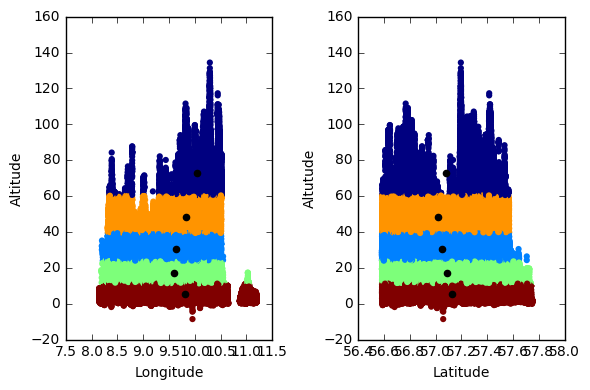

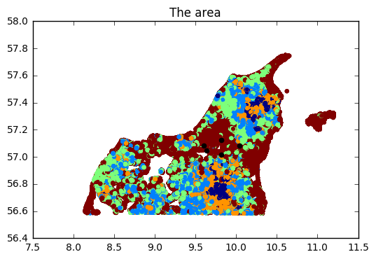

```python
originalData = pandas.read_csv('3D_spatial_network.txt', sep=',', header=None)
analysisData = originalData.ix[:,1:].T.values

groups, centers, interCluster, intraClusterAvg, intraClusterMax = KMeans(5, analysisData, printInfo=True)

plt.subplot(1,2,1)
plt.scatter(analysisData[0,:], analysisData[2,:], c=groups, marker='o', lw = 0)
plt.scatter(centers[0,:], centers[2,:], c="Black", marker='o', lw = 1)
plt.xlabel("Longitude")
plt.ylabel("Altitude")

plt.subplot(1,2,2)
plt.scatter(analysisData[1,:], analysisData[2,:], c=groups, marker='o', lw = 0)
plt.scatter(centers[1,:], centers[2,:], c="Black", marker='o', lw = 1)
plt.xlabel("Latitude")
plt.ylabel("Altutude")

plt.tight_layout()
plt.show()

plt.scatter(analysisData[0,:], analysisData[1,:], c=groups, marker='o', lw = 0)
plt.scatter(centers[0,:], centers[1,:], c="Black", marker='o', lw = 1)
plt.title("The area")
plt.show()
```

## 8 groups

Poziomica mniej czytelna, ale bardziej szczegółowa

```
Iterations: 219

Group sizes:
 [ 43738   6810  18231  31619  70232  64095 118232  81917]

Inter cluster distances:
[[  0.00000000e+00   2.18999795e+03   7.33536759e+02   1.40333283e+02
    3.40684485e+02   9.58086880e+01   1.16372109e+03   7.03441122e+02]
 [  2.18999795e+03   0.00000000e+00   3.88629565e+02   1.22159961e+03
    4.25818442e+03   3.20187419e+03   6.54615877e+03   5.37562638e+03]
 [  7.33536759e+02   3.88629565e+02   0.00000000e+00   2.32188682e+02
    2.07400284e+03   1.35951304e+03   3.74481531e+03   2.87350809e+03]
 [  1.40333283e+02   1.22159961e+03   2.32188682e+02   0.00000000e+00
    9.18306727e+02   4.68028605e+02   2.11212006e+03   1.47207866e+03]
 [  3.40684485e+02   4.25818442e+03   2.07400284e+03   9.18306727e+02
    0.00000000e+00   7.51630115e+01   2.45190566e+02   6.50654812e+01]
 [  9.58086880e+01   3.20187419e+03   1.35951304e+03   4.68028605e+02
    7.51630115e+01   0.00000000e+00   5.91754160e+02   2.80045172e+02]
 [  1.16372109e+03   6.54615877e+03   3.74481531e+03   2.11212006e+03
    2.45190566e+02   5.91754160e+02   0.00000000e+00   5.76455410e+01]
 [  7.03441122e+02   5.37562638e+03   2.87350809e+03   1.47207866e+03
    6.50654812e+01   2.80045172e+02   5.76455410e+01   9.09494702e-13]]

Intra cluster average distance to center
 [ 2.79768631  6.8281551   4.33506375  3.34908331  2.25721718  2.38709669
  1.89904172  2.09714514]

Intra cluster maximum distance to center
 [  6.07498316  49.49724635   9.90149068   7.75306166   4.54900648
   5.04783465  12.64593838   4.24920328]
```

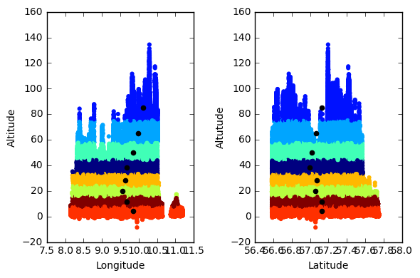

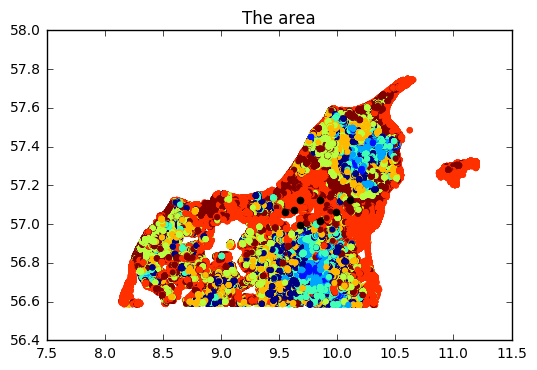

```python
originalData = pandas.read_csv('3D_spatial_network.txt', sep=',', header=None)
analysisData = originalData.ix[:,1:].T.values

groups, centers, interCluster, intraClusterAvg, intraClusterMax = KMeans(8, analysisData, printInfo=True)

plt.subplot(1,2,1)
plt.scatter(analysisData[0,:], analysisData[2,:], c=groups, marker='o', lw = 0)
plt.scatter(centers[0,:], centers[2,:], c="Black", marker='o', lw = 1)
plt.xlabel("Longitude")
plt.ylabel("Altitude")

plt.subplot(1,2,2)
plt.scatter(analysisData[1,:], analysisData[2,:], c=groups, marker='o', lw = 0)
plt.scatter(centers[1,:], centers[2,:], c="Black", marker='o', lw = 1)
plt.xlabel("Latitude")
plt.ylabel("Altutude")

plt.tight_layout()
plt.show()

plt.scatter(analysisData[0,:], analysisData[1,:], c=groups, marker='o', lw = 0)
plt.scatter(centers[0,:], centers[1,:], c="Black", marker='o', lw = 1)
plt.title("The area")
plt.show()
```

[figure not shown]

```python
Image(filename="denmarkMap.jpg")
```

## Normalized data, 5 groups

Poprzednio wysokość decydowała o grupowaniu. Znormalizowaliśmy dane i zobaczmy, co się stanie. Grupowanie wygląda jak zwykły K-Means - powstały obszary Voronoi'a. Jednakże powstała jedna dziwna, mała grupa reprezentująca góry.

```
Iterations: 35

Group sizes:
 [ 36413  94930  95579  81772 126180]

Inter cluster distances:
[[  5.55111512e-17   9.12084687e-02   4.68849635e-01   2.78801671e-01
    1.45710810e-01]
 [  9.12084687e-02   0.00000000e+00   5.47506351e-01   4.19059532e-01
    1.33507013e-01]
 [  4.68849635e-01   5.47506351e-01   5.55111512e-17   1.37452398e-01
    1.63940969e-01]
 [  2.78801671e-01   4.19059532e-01   1.37452398e-01  -2.77555756e-17
    1.04787606e-01]
 [  1.45710810e-01   1.33507013e-01   1.63940969e-01   1.04787606e-01
    0.00000000e+00]]

Intra cluster average distance to center
 [ 0.14203407  0.15868466  0.16727301  0.17436277  0.14201032]

Intra cluster maximum distance to center
 [ 0.57824165  0.33594305  0.49113906  0.52211191  0.361426  ]
```

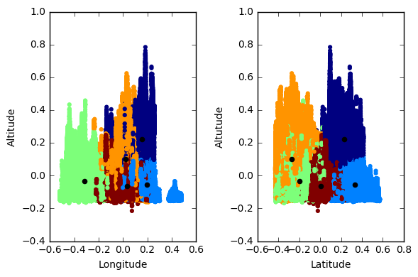

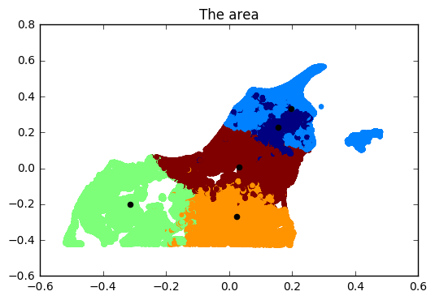

```python
originalData = pandas.read_csv('3D_spatial_network.txt', sep=',', header=None)
analysisData = originalData.ix[:,1:].T.values
analysisData = (analysisData - analysisData.mean(axis=1, keepdims=True)) / (analysisData.max(axis=1, keepdims=True) - analysisData.min(axis=1, keepdims=True))

groups, centers, interCluster, intraClusterAvg, intraClusterMax = KMeans(5, analysisData, printInfo=True)

plt.subplot(1,2,1)
plt.scatter(analysisData[0,:], analysisData[2,:], c=groups, marker='o', lw = 0)
plt.scatter(centers[0,:], centers[2,:], c="Black", marker='o', lw = 1)
plt.xlabel("Longitude")
plt.ylabel("Altitude")

plt.subplot(1,2,2)
plt.scatter(analysisData[1,:], analysisData[2,:], c=groups, marker='o', lw = 0)
plt.scatter(centers[1,:], centers[2,:], c="Black", marker='o', lw = 1)
plt.xlabel("Latitude")
plt.ylabel("Altutude")

plt.tight_layout()
plt.show()

plt.scatter(analysisData[0,:], analysisData[1,:], c=groups, marker='o', lw = 0)
plt.scatter(centers[0,:], centers[1,:], c="Black", marker='o', lw = 1)
plt.title("The area")
plt.show()
```

```
Iterations: 66

Group sizes:
 [37422 39582 56670 43677 32021 53951 27019 23299 42751 78482]

Inter cluster distances:
[[  0.00000000e+00   2.18313513e-01   3.48810785e-01   8.51462735e-02
    4.08415854e-02   5.94623380e-01   4.56329661e-01   2.66884287e-01
    9.05455566e-02   2.06671402e-01]
 [  2.18313513e-01   0.00000000e+00   3.11387715e-01   7.53582727e-02
    2.27895175e-01   4.83585637e-01   2.22121511e-01   7.33498148e-02
    1.70304337e-01   1.20373791e-01]
 [  3.48810785e-01   3.11387715e-01  -2.77555756e-17   3.88557906e-01
    5.54089986e-01   4.88007986e-02   7.33915896e-02   3.52744271e-01
    1.01494105e-01   1.09284999e-01]
 [  8.51462735e-02   7.53582727e-02   3.88557906e-01   0.00000000e+00
    5.41083170e-02   5.81327254e-01   4.21460542e-01   6.73411795e-02
    1.19707596e-01   1.24977155e-01]
 [  4.08415854e-02   2.27895175e-01   5.54089986e-01   5.41083170e-02
    0.00000000e+00   8.18119313e-01   6.49640614e-01   2.33818482e-01
    1.89461759e-01   2.79076971e-01]
 [  5.94623380e-01   4.83585637e-01   4.88007986e-02   5.81327254e-01
    8.18119313e-01   0.00000000e+00   1.55776102e-01   4.45169131e-01
    2.25257434e-01   1.74344802e-01]
 [  4.56329661e-01   2.22121511e-01   7.33915896e-02   4.21460542e-01
    6.49640614e-01   1.55776102e-01   0.00000000e+00   3.59442655e-01
    2.12434206e-01   1.75943225e-01]
 [  2.66884287e-01   7.33498148e-02   3.52744271e-01   6.73411795e-02
    2.33818482e-01   4.45169131e-01   3.59442655e-01   0.00000000e+00
    1.67250701e-01   7.51057587e-02]
 [  9.05455566e-02   1.70304337e-01   1.01494105e-01   1.19707596e-01
    1.89461759e-01   2.25257434e-01   2.12434206e-01   1.67250701e-01
    0.00000000e+00   4.07635936e-02]
 [  2.06671402e-01   1.20373791e-01   1.09284999e-01   1.24977155e-01
    2.79076971e-01   1.74344802e-01   1.75943225e-01   7.51057587e-02
    4.07635936e-02   0.00000000e+00]]

Intra cluster average distance to center
 [ 0.11033627  0.13892773  0.1169878   0.12429612  0.12392124  0.13823082
  0.12972158  0.11299228  0.12349857  0.10154823]

Intra cluster maximum distance to center
 [ 0.39471639  0.41880362  0.23232302  0.27470059  0.48682575  0.28985265
  0.53961043  0.23105882  0.31421649  0.2328028 ]
```

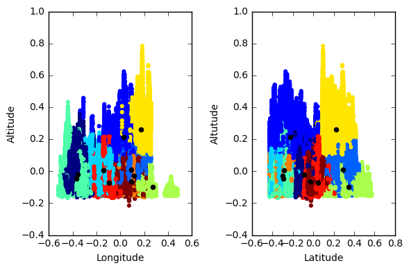

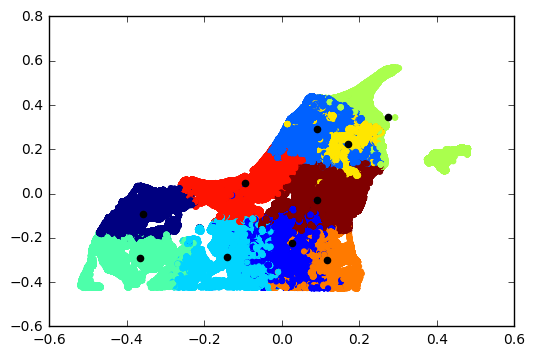

```python
originalData = pandas.read_csv('3D_spatial_network.txt', sep=',', header=None)
analysisData = originalData.ix[:,1:].T.values
analysisData = (analysisData - analysisData.mean(axis=1, keepdims=True)) / (analysisData.max(axis=1, keepdims=True) - analysisData.min(axis=1, keepdims=True))

groups, centers, interCluster, intraClusterAvg, intraClusterMax = KMeans(10, analysisData, printInfo=True)

plt.subplot(1,2,1)
plt.scatter(analysisData[0,:], analysisData[2,:], c=groups, marker='o', lw = 0)
plt.scatter(centers[0,:], centers[2,:], c="Black", marker='o', lw = 1)
plt.xlabel("Longitude")
plt.ylabel("Altitude")

plt.subplot(1,2,2)
plt.scatter(analysisData[1,:], analysisData[2,:], c=groups, marker='o', lw = 0)
plt.scatter(centers[1,:], centers[2,:], c="Black", marker='o', lw = 1)
plt.xlabel("Latitude")
plt.ylabel("Altutude")

plt.tight_layout()
plt.show()

plt.scatter(analysisData[0,:], analysisData[1,:], c=groups, marker='o', lw = 0)
plt.scatter(centers[0,:], centers[1,:], c="Black", marker='o', lw = 1)
plt.show()
```

## Normalized only altitude, 10 groups

Długość i szerokość geograficzna zmieniają się nieznacznie - warto sprawdzić, co się stanie jeśli znormalizujemy tylko wysokość. Grupy z K-Means ułożyły się względem długości geograficznej, która w największym stopniu wpływa na odległość wektorów.

```
Iterations: 93

Group sizes:
 [63983 42010 52758 42731 41449 32891 38412 32649 49412 38579]

Inter cluster distances:
[[  0.00000000e+00   1.84316805e-01   5.98659038e-01   1.19737741e+00
    2.39758249e-01   9.71893497e-02   1.59493784e-01   1.21468793e-01
    4.05002993e-01   2.17420925e+00]
 [  1.84316805e-01  -9.09494702e-13   3.75300313e-01   1.62145750e+00
    1.31722999e-01   4.34465875e-01   5.75346342e-01   1.92568799e-01
    7.64315632e-01   2.61321877e+00]
 [  5.98659038e-01   3.75300313e-01   0.00000000e+00   3.33605893e+00
    1.84139994e-01   5.57878413e-01   1.25399445e+00   9.61054538e-01
    1.92762295e+00   4.79618195e+00]
 [  1.19737741e+00   1.62145750e+00   3.33605893e+00   0.00000000e+00
    2.27131105e+00   1.73633342e+00   8.73813872e-01   7.25247247e-01
    2.13696581e-01   1.49602396e-01]
 [  2.39758249e-01   1.31722999e-01   1.84139994e-01   2.27131105e+00
    0.00000000e+00   3.00669995e-01   5.90484615e-01   4.87478530e-01
    1.14247506e+00   3.49296823e+00]
 [  9.71893497e-02   4.34465875e-01   5.57878413e-01   1.73633342e+00
    3.00669995e-01   0.00000000e+00   2.38326111e-01   4.27675006e-01
    7.37554712e-01   2.90454733e+00]
 [  1.59493784e-01   5.75346342e-01   1.25399445e+00   8.73813872e-01
    5.90484615e-01   2.38326111e-01   0.00000000e+00   2.86988274e-01
    2.54256520e-01   1.71678275e+00]
 [  1.21468793e-01   1.92568799e-01   9.61054538e-01   7.25247247e-01
    4.87478530e-01   4.27675006e-01   2.86988274e-01   0.00000000e+00
    2.03281376e-01   1.46386200e+00]
 [  4.05002993e-01   7.64315632e-01   1.92762295e+00   2.13696581e-01
    1.14247506e+00   7.37554712e-01   2.54256520e-01   2.03281376e-01
    9.09494702e-13   7.17640939e-01]
 [  2.17420925e+00   2.61321877e+00   4.79618195e+00   1.49602396e-01
    3.49296823e+00   2.90454733e+00   1.71678275e+00   1.46386200e+00
    7.17640939e-01  -9.09494702e-13]]

Intra cluster average distance to center
 [ 0.1302167   0.15079485  0.23749854  0.2051156   0.19728021  0.19403365
  0.19831822  0.13931284  0.21000001  0.19481048]

Intra cluster maximum distance to center
 [ 0.36596792  0.47169444  0.639991    0.5004648   0.62981074  0.37806302
  0.44017759  0.40020375  0.50165194  0.47472341]
```

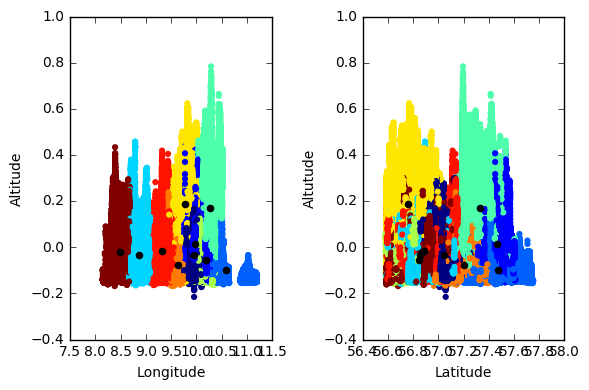

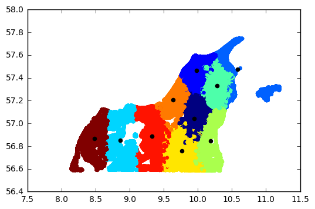

```python
originalData = pandas.read_csv('3D_spatial_network.txt', sep=',', header=None)
analysisData = originalData.ix[:,1:].T.values
analysisData[2,:] = (analysisData[2,:] - analysisData[2,:].mean()) / (analysisData[2,:].max() - analysisData[2,:].min())

groups, centers, interCluster, intraClusterAvg, intraClusterMax = KMeans(10, analysisData, printInfo=True)

plt.subplot(1,2,1)
plt.scatter(analysisData[0,:], analysisData[2,:], c=groups, marker='o', lw = 0)
plt.scatter(centers[0,:], centers[2,:], c="Black", marker='o', lw = 1)
plt.xlabel("Longitude")
plt.ylabel("Altitude")

plt.subplot(1,2,2)
plt.scatter(analysisData[1,:], analysisData[2,:], c=groups, marker='o', lw = 0)
plt.scatter(centers[1,:], centers[2,:], c="Black", marker='o', lw = 1)
plt.xlabel("Latitude")
plt.ylabel("Altutude")

plt.tight_layout()
plt.show()

plt.scatter(analysisData[0,:], analysisData[1,:], c=groups, marker='o', lw = 0)
plt.scatter(centers[0,:], centers[1,:], c="Black", marker='o', lw = 1)
plt.show()
```